# MPDW Praktikum 6

# Library

```r
library(forecast)
library(tseries)
```

```r
library(ggplot2)
library(Metrics)
library(readxl)
library(TSA)
```

# Persiapan Data

## Membaca Data

```r
data <- read.csv2("usd_idr_daily_2022.csv", sep = ",")

data$Date <- as.Date(data$Date)
data$Close <- as.numeric(data$Close)
data$Open <- as.numeric(data$Open)
data$Low <- as.numeric(data$Low)
data$High <- as.numeric(data$High)

head(data)
```

```
##         Date    Open    High     Low   Close
## 1 2022-01-03 14246.0 14301.3 14207.5 14215.0
## 2 2022-01-04 14303.7 14383.3 14259.0 14283.6
## 3 2022-01-05 14346.4 14398.5 14336.7 14385.5
## 4 2022-01-06 14445.8 14445.8 14351.0 14446.5
## 5 2022-01-07 14408.0 14408.0 14320.5 14408.0
## 6 2022-01-10 14351.0 14351.0 14262.3 14318.5
```

Variabel yang digunakan adalah harga penutupan (Close) karena ingin melakukan peramalan nilai penutupan USD/IDR.

## Membuat Data Time Series

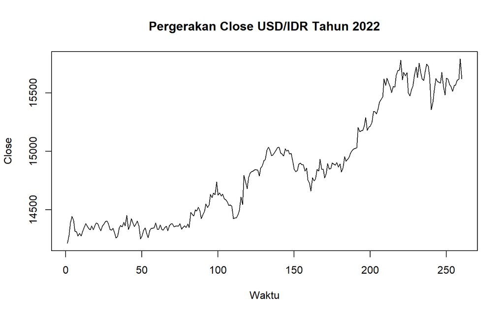

```r
close_ts <- ts(
  data$Close,
  frequency = 1
)

plot(
  close_ts,
  main = "Pergerakan Close USD/IDR Tahun 2022",
  ylab = "Close",
  xlab = "Waktu"
)
```

Grafik menunjukkan perubahan nilai Close USD/IDR dari waktu ke waktu. Terlihat bahwa data mengalami fluktuasi sehingga diperlukan model deret waktu untuk menangkap pola historis sebelum melakukan peramalan.

## Pembagian Data Training dan Testing

```r
n <- length(close_ts)

train_size <- floor(0.8*n)

train <- window(
  close_ts,
  end = train_size
)

test <- window(
  close_ts,
  start = train_size + 1
)

length(train)
```

```
## [1] 208
```

```r
length(test)
```

```
## [1] 52
```

Data dibagi menjadi dua bagian, yaitu 80% data awal sebagai data training untuk membangun model ARIMA dan 20% data akhir sebagai data testing untuk mengevaluasi kemampuan prediksi model ARIMA.

# Model ARIMA

## Cek Stasioneritas

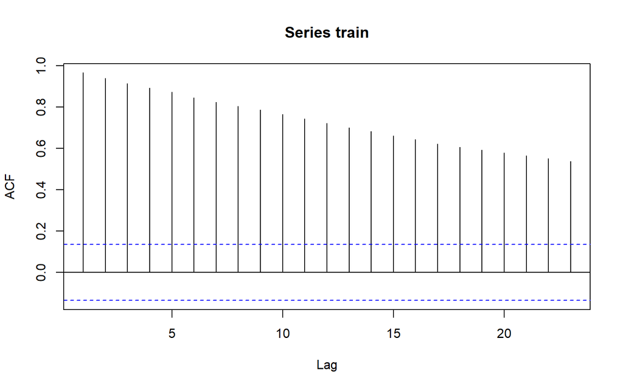

```r
acf(train)
```

Berdasarkan plot ACF, terlihat bahwa plot ACF data menurun secara perlahan (tails of slowly). Hal ini juga menjadi indikasi bahwa data tidak stasioner dalam rataan

```r
adf.test(train)
```

```
##
##  Augmented Dickey-Fuller Test
##
## data:  train
## Dickey-Fuller = -1.9938, Lag order = 5, p-value = 0.5786
## alternative hypothesis: stationary
```

H0 : Data tidak stasioner dalam rataan H1 : Data stasioner dalam rataan

Karena p-value > 0.05, maka data belum stasioner akan dilakukan diferrencing agar menjadi stasioner

## Differencing

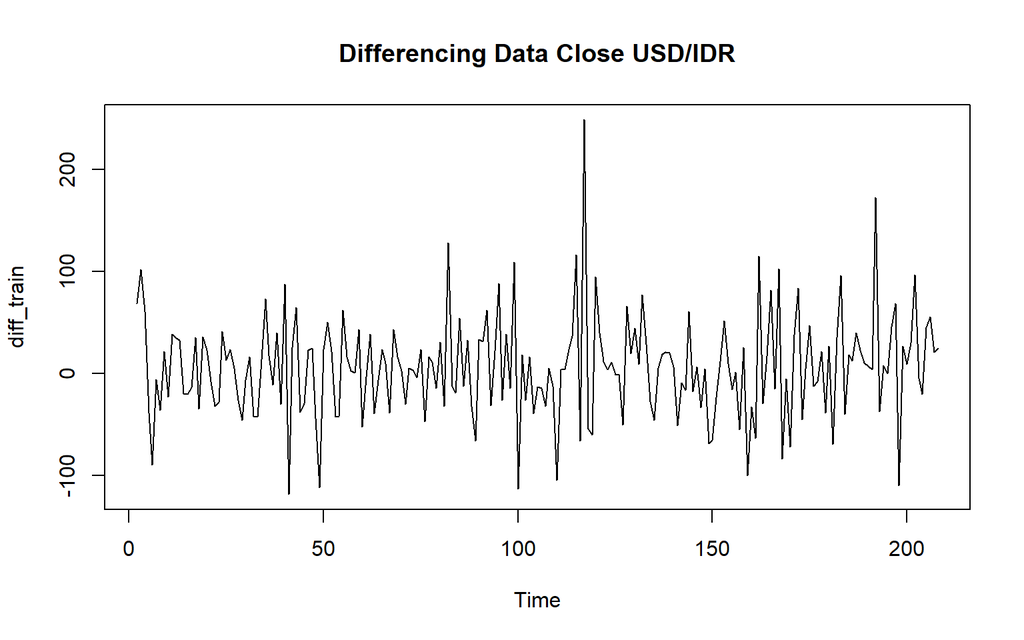

```r
diff_train <- diff(train)

plot(
  diff_train,
  main="Differencing Data Close USD/IDR"
)
```

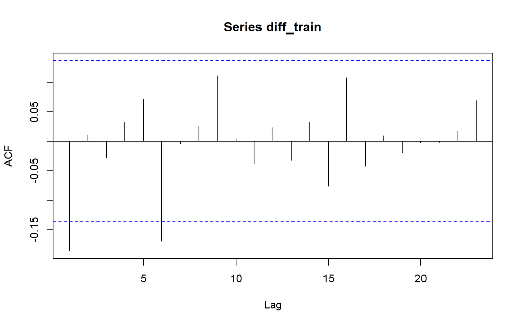

```r
acf(diff_train)
```

Berdasarkan plot tersebut, terlihat bahwa plot ACF cuts off pada lag ke 1. Hal ini menandakan data sudah stasioner dalam rataan dan ketidakstasioneran data telah berhasil tertangani.

```r
adf.test(diff_train)
```

```
##
##  Augmented Dickey-Fuller Test
##
## data:  diff_train
## Dickey-Fuller = -6.3067, Lag order = 5, p-value = 0.01
## alternative hypothesis: stationary
```

H0 : Data tidak stasioner dalam rataan

H1 : Data stasioner dalam rataan

Karena p-value < 0.05, maka data sudah lebih stasioner

Differencing dilakukan untuk menghilangkan pola tren sehingga rata-rata data menjadi lebih stabil. Setelah proses differencing, data menjadi lebih stasioner. Dapat dilihat pada plot tersebut

## Menentukan Model ARIMA

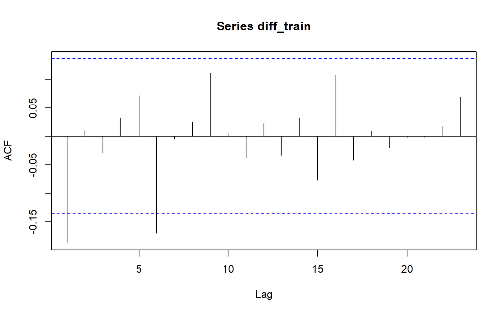

```r
acf(diff_train)
```

Plot acf cut-off pada lag 1, maka q=1

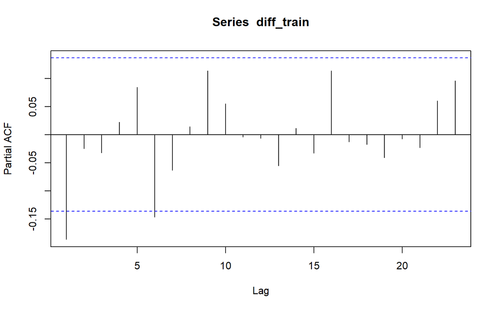

```r
## EACF
pacf(diff_train)
```

Plot pacf cut-off pada lag 1, maka p=1

### EACF

```r
eacf(diff_train)
```

```
## AR/MA
##   0 1 2 3 4 5 6 7 8 9 10 11 12 13
## 0 x o o o o x o o o o o  o  o  o
## 1 x o o o o x o o o o o  o  o  o
## 2 x x o o o x o o o o o  o  o  o
## 3 x x o o o o o o o o o  o  o  o
## 4 x x o o o o o o o o o  o  o  o
## 5 x x x x x o o o o o o  o  o  o
## 6 x x x o o o o o o o o  o  o  o
## 7 o x x x o o o o o o o  o  o  o
```

### Model ARIMA dengan auto.arima

```r
model_auto <- auto.arima(
  train,
  seasonal = FALSE,
  stepwise = FALSE,
  approximation = FALSE
)

model_auto
```

```
## Series: train
## ARIMA(0,1,1) with drift
##
## Coefficients:
##           ma1   drift
##       -0.1939  5.9447
## s.e.   0.0689  2.7503
##
## sigma^2 = 2428:  log likelihood = -1099.46
## AIC=2204.91   AICc=2205.03   BIC=2214.91
```